# Propuesta de mejora de tiempo en proceso de gestión y control de inventario, mediante la implementación de WMS para el caso de área de almacén del taller de servicio mecánico integral y electricidad automotriz DUARCON

ANTEPROYECTO PARA SEMINARIO DE TITULO PARA LA OBTENCIÓN DEL TITULO INGENIERO CIVIL INDUSTRIAL

Felipe Kiefer

# 1 Nombre del seminario

Propuesta de mejora del proceso de gestión y control de inventario, mediante la implementación de WMS, para el caso de área de almacén del taller de servicio mecánico integral y electricidad automotriz DUARCON.

# 2 Fundamentos

## 2.1 antecedentes, situación actual mercado automóvil

El inicio de la pandemia del COVID-19 a afectado la venta de automóvil, el primer semestre del año 2020 hubo una reducción en la compra de vehículos livianos y medianos. la figura @ref(fig:vauto) presenta las ventas del mercado automotor de livianos y medianos, realizado por Asociación Nacional Automotriz de Chile (ANAC).

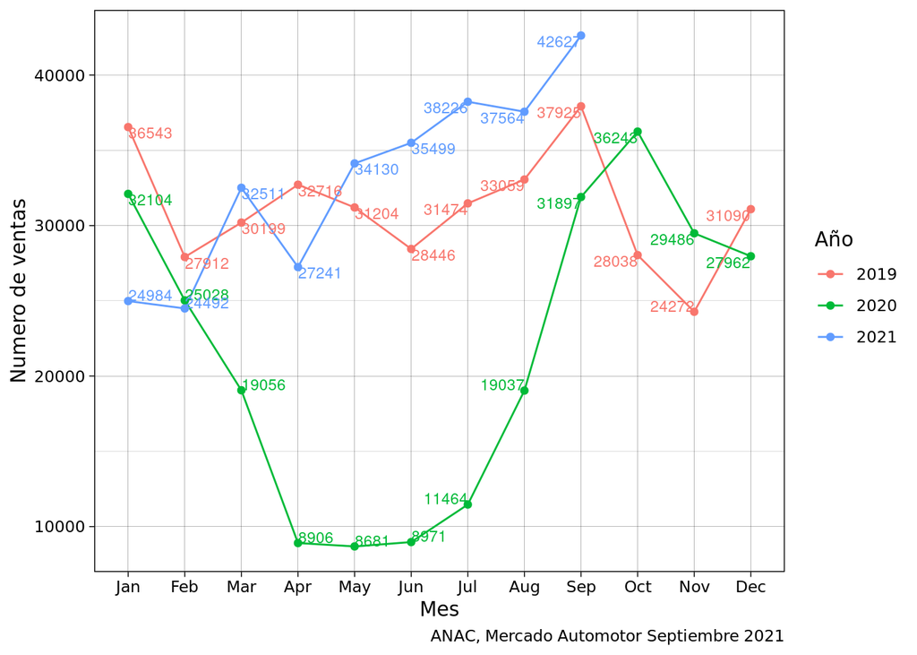

Ventas mensuales a publico del mercado de livianos y medianos

Se puede observar un aumento en el consumo desde el segundo semestre del 2020, ademas el parque de automotriz se acelera y rozará los 5,5 millones de unidades este año. Esto en un contexto de mayor liquidez por los retiros del 10% de las AFP y también del uso de vehículos para actividades laborales como las de reparto y servicios de movilización privada (V, 2021). En consecuencia se espera un aumento en la demanda de los servicios de mantenimiento y reparación automotriz lo cual es el servicio que entrega Duarcon.

## 2.2 Descripción del taller

Duarcon.Ltda es una pequeña empresa dedicada la reparación mecánica y eléctrica automotriz, su mercado objetivo es el vehículo mediano, esta ubicada en la comuna de Quilicura, el taller cuenta con una plantilla 5 trabajadores (1 administrador, 4 mecánicos), estructurados tal como muestra la figura @ref(fig:estruc). El modelo de proceso del servicio se realiza como muestra la figura @ref(fig:bpmn).

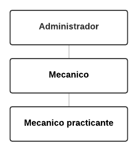

Estructura organizacional

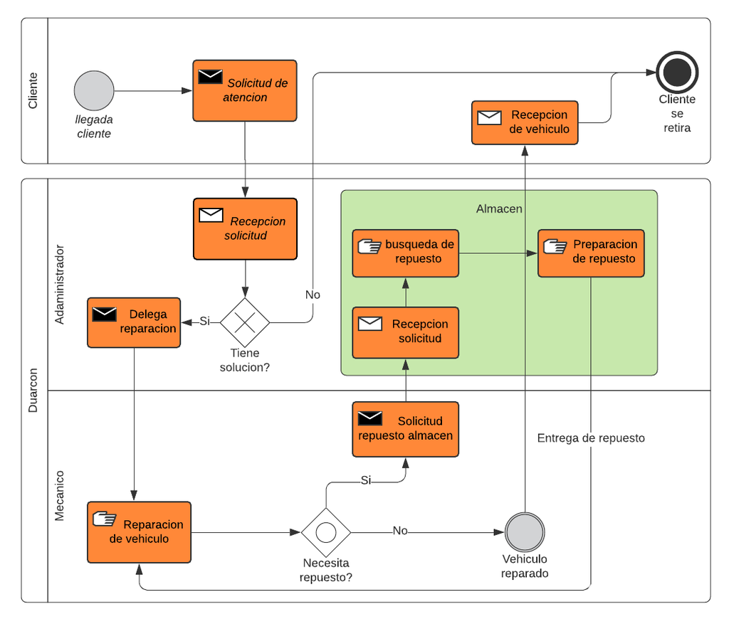

BPMN de servicio reparacion

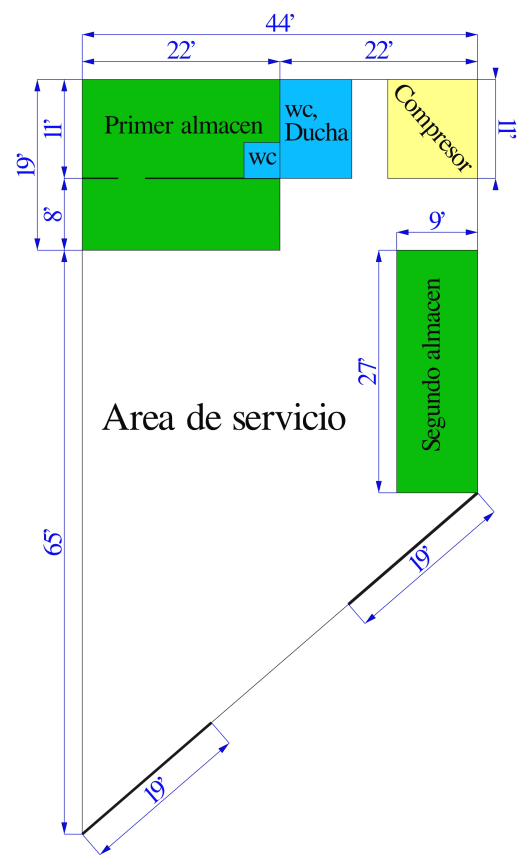

layout taller

## 2.3 justificación

Hasta el primer semestre el almacén era de 418 ft<sup>2</sup>, en el segundo semestre realiza una ampliación del área de almacén de 243 ft<sup>2</sup>, lo que da un total de 661 ft<sup>2</sup> de plaza para almacén, la figura @ref(fig:layout) muestra un plano de la distribución del taller.